# Project 1: Covid Study

### 3 variable

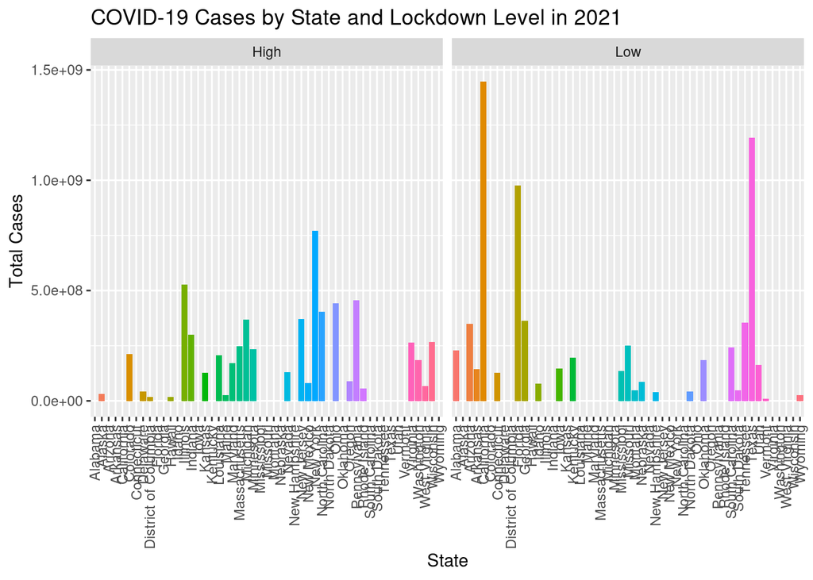

```r
covidData_2021 %>%    # Figure 3
  ggplot(aes(x=state, y=totCases, fill=state)) +
  geom_bar(stat="identity") +
  facet_wrap(~lockdown_level) +
  xlab("State") +
  ylab("Total Cases") +
  ggtitle("COVID-19 Cases by State and Lockdown Level in 2021") +
  theme(axis.text.x = element_text(angle = 90, vjust = 0.5, hjust = 1),
        legend.position = "none")
```

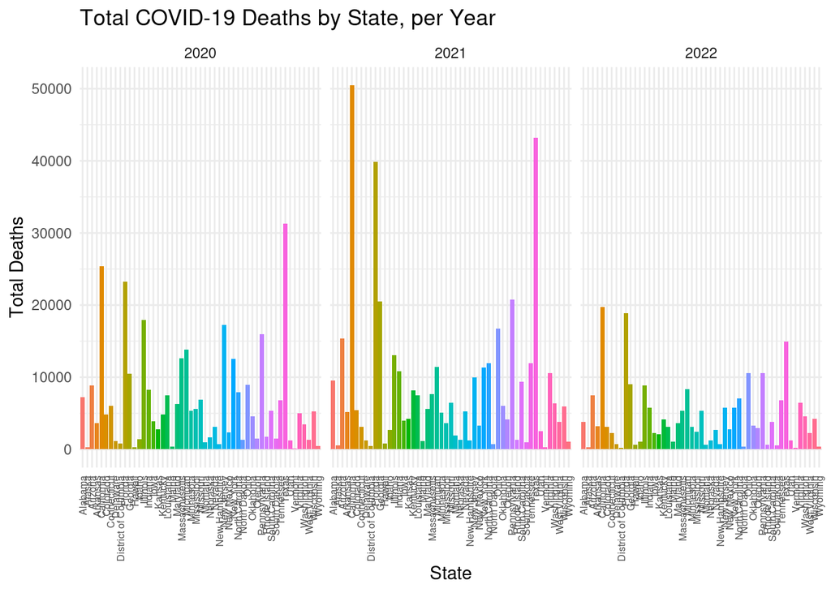

```r
covidData %>%    # Figure 2
  ggplot(aes(x = state, y = newDeaths, fill = state)) +
  geom_bar(stat = "identity") +
  facet_wrap(~year) +
  labs(title = "Total COVID-19 Deaths by State, per Year", x = "State",
       y = "Total Deaths") +
  theme_minimal() +
  theme(axis.text.x = element_text(angle = 90, vjust = 0.5, hjust = 1)) +
  theme(axis.text.x = element_text(size = 6), legend.position = "none")
```

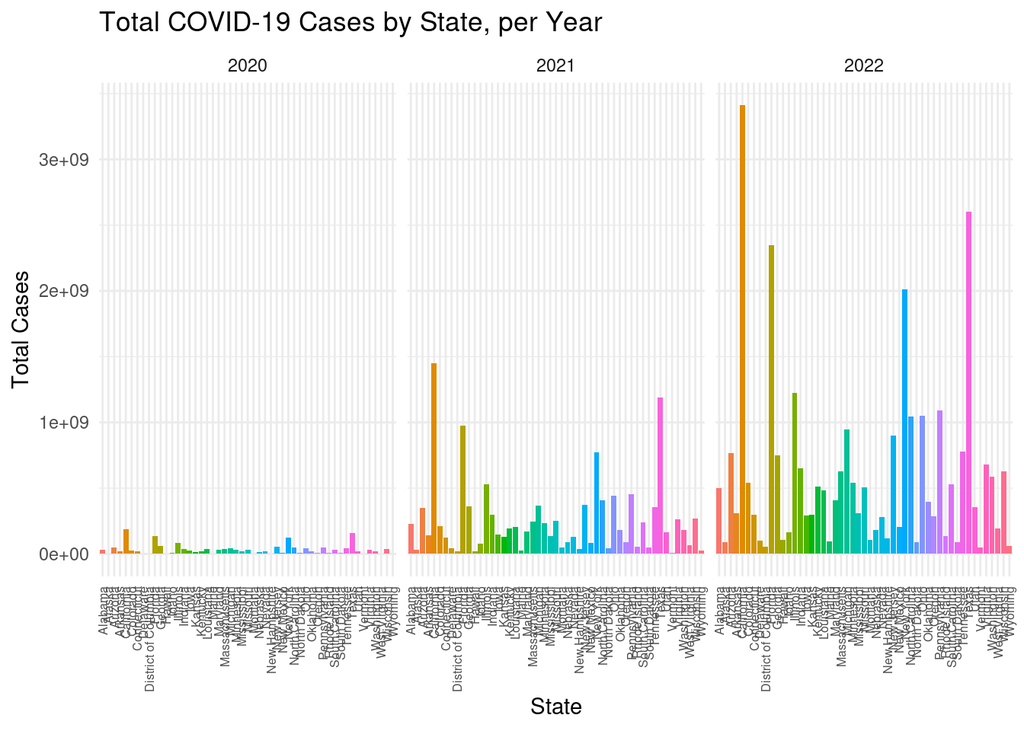

```r
covidData %>%    # Figure 1
  ggplot(aes(x = state, y = totCases, fill = state)) +
  geom_bar(stat = "identity") +
  facet_wrap(~year) +
  labs(title = "Total COVID-19 Cases by State, per Year", x = "State",
       y = "Total Cases") +
  theme_minimal() +
  theme(axis.text.x = element_text(angle = 90, vjust = 0.5, hjust = 1)) +
  theme(axis.text.x = element_text(size = 6), legend.position = "none")
```

## Discussion

Each figure shows how cases, new deaths, and lockdown precautions vary by state. We can use these insights to answer our research questions. Figures 1 and 2 chart the progression of COVID cases and deaths over time. In figure 1, we see that COVID cases increase dramatically for all states across all three years of our study. Interestingly, however, figure 2 shows a decrease in COVID deaths after 2021. This is likely due to vaccines, less deadlier strains, and other factors that effectively made COVID less lethal. Additionally, Figure 3 shows a correlation between number of COVID cases per state and severity of lockdown restrictions; states with higher lockdown levels faced fewer cases in 2021. This decrease in infection could be caused by the strict mandates, although it isn’t unlikely that people in states with more strict lockdowns are also warier of COVID’s spread. It’s difficult to separate correlation from causation with our limited data.

In hindsight, we had a difficult time tidying our data. It wasn’t easy to determine when our datasets were tidy, especially when working with such large amounts of information. It might be useful to trim unused data before tidying to make tidying data easier in the future. We also had a bit of a hard time making some of our visualizations. There are a lot of intricacies in ggplot2 where a small change can dramatically affect the final product. It was challenging to create attractive visuals, but we did grow more confident using ggplot’s more esoteric commands like facet_wrap() and theme().

### Acknowledgements

Each group member found, tidied, and wrangled our own datasets. Reagan sourced the data for the number of total COVID cases for each year, Max found the data for the number of deaths, and Joseph found the data for the mandates imposed by each state. From there, Joseph joined the separate datasets into the master dataset used for this report. Reagan and Max created the visuals for each dataset and Joseph aggregated everything into a single document for our report.